# Session 5 — Assumptions and Reporting

Proportional hazards · Schoenfeld residuals · strata and time-split fixes · censoring · reporting · Lab 5

Community Medicine Workshop

## Where we are

- Session 4: the Cox model and hazard ratios
- Today: **can we trust a single hazard ratio?**
- By the end you can:
  - **test and plot** the proportional-hazards assumption
  - **fix** a violation by **stratifying** or **splitting time**
  - judge whether **censoring** is acceptable
  - **report** a survival analysis

# Topic 1 — Proportional hazards

## The assumption

The Cox model assumes the **hazard ratio is constant over time**. If one group is worse **early** and the same **later**, a single HR averages two different stories.

```r
fit <- coxph(Surv(time_months, status) ~ age + sex + hiv + diabetes + smoker + bmi + mdr_tb + smear + treatment, data = tb)
zph <- cox.zph(fit)
round(zph$table, 3)
```

```
           chisq df     p
age        5.785  1 0.016
sex        0.008  1 0.928
hiv        0.276  1 0.600
diabetes   1.293  1 0.256
smoker     1.677  1 0.195
bmi        3.970  1 0.046
mdr_tb     0.022  1 0.881
smear     15.317  1 0.000
treatment  2.734  1 0.098
GLOBAL    30.465  9 0.000
```

## Reading the test

- `cox.zph()` tests whether **Schoenfeld residuals** trend with time, **one p-value per term** plus a global one
- **smear** has a very small p-value: its effect **changes over time**
- With nine terms tested, **borderline** p-values (age, BMI) can be **chance**: **look at the plot** before acting

## Look at it

```r
plot(zph[8]); abline(h = 0, col = "red")
```

- A **flat line** means a constant log hazard ratio
- Here the curve **slopes down**: strong effect early, little later
- A second look: **log-log plot** of the curves; **parallel** lines support proportional hazards

## Look at it

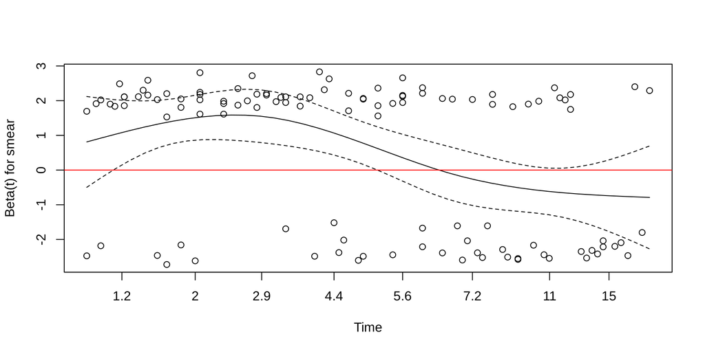

# Topic 2 — Fixing a violation

## Fix 1: stratify

```r
cox_strat <- coxph(Surv(time_months, status) ~ age + sex + hiv + diabetes + smoker + bmi + mdr_tb + treatment + strata(smear), data = tb)
round(exp(coef(cox_strat)), 2)
```

```
         age      sexMale  hivPositive  diabetesYes    smokerYes          bmi
        1.02         1.07         2.01         1.33         1.10         0.91
   mdr_tbYes treatmentDOT
        2.36         0.57
```

- `strata(smear)`: a **separate baseline hazard** for each group, so the other HRs are not distorted
- **You lose** an HR for smear itself, which is a reasonable price if smear is only a **nuisance** variable
- Use for a **categorical** variable

## Fix 2: split time and estimate the effect in each period

```r
tb_split <- survSplit(Surv(time_months, status) ~ ., data = tb, cut = 6, episode = "period")
tb_split$smear_pos <- as.numeric(tb_split$smear == "Positive")
cox_split <- coxph(Surv(tstart, time_months, status) ~ age + sex + hiv + diabetes + smoker + bmi + mdr_tb + treatment + smear_pos:factor(period), data = tb_split)
round(exp(coef(cox_split))[c("smear_pos:factor(period)1", "smear_pos:factor(period)2")], 2)
```

```
smear_pos:factor(period)1 smear_pos:factor(period)2
                     3.28                      0.58
```

“Smear-positive disease **tripled the hazard in the first 6 months** (HR about 3) and was **not harmful afterwards** (HR about 0.6).” The **effect of time** is itself a finding. Other options: **time-varying covariates**, **landmark analysis**, **parametric models**.

# Topic 3 — Censoring and reporting

## Is censoring “non-informative”?

- Kaplan-Meier and Cox assume patients **censored at time t** have the **same future risk** as those who remain
- If the **sickest** are **lost to follow-up**, the curve is **too optimistic**
- Check: **how many** were lost, **who** (compare groups), and **when**
- **Sensitivity analysis:** treat everyone lost as dead (worst case) and as alive (best case)

```r
tb |> group_by(hiv) |> summarise(n = n(), pct_lost = round(100 * mean(censor_reason %in% "Lost to follow-up"), 1))
```

```
# A tibble: 2 × 3
  hiv          n pct_lost
  <fct>    <int>    <dbl>
1 Negative   537     17.3
2 Positive    63     15.9
```

## Other threats

| Problem | What to do |
| --- | --- |
| **Competing risks** (death from another cause stops the event of interest) | cumulative incidence (`tidycmprsk`), Fine-Gray model; beyond this workshop |
| **Immortal time bias** (time before exposure counted as exposed) | define **time zero** carefully; time-varying exposure |
| **Different time zero** for groups | use the **same** starting point (e.g. start of treatment) |
| **Too many covariates** for the events | fewer predictors; shrinkage |

## Reporting checklist

1. **Population, time zero, event, end of follow-up**; number of patients, events, censored
2. **Median follow-up** (reverse KM) and **reasons for censoring**
3. **Kaplan-Meier** curves with number at risk; survival at fixed times with CI
4. **Cox model:** crude and adjusted HRs with CI, reference groups, units
5. **Proportional-hazards check** and what you did about violations
6. **Limitations:** informative censoring, competing risks, confounding, **association, not cause**

## 🔧 Switch to R — Lab 5

**File:** `survival-workshop/labs/lab5_assumptions.R`

- `cox.zph()` · plot the Schoenfeld residuals · log-log plot
- `strata()` and `survSplit()` fixes
- lost to follow-up by group · final hazard-ratio table

**Time:** 40 minutes · answer the Q questions in the comments

## Self-check quiz (1/5)

cox.zph() gives p = 0.0001 for the smear-status term. What does this mean?

- Smear status has no effect on survival at any time during follow-up
- The Cox model cannot be fitted to these data until smear is removed
- The hazard ratio for smear is not constant over follow-up time
- Smear status should be removed from the data set before analysis

## Self-check quiz (2/5)

Which is an appropriate response to a proportional-hazards violation for a nuisance categorical variable?

- Delete the variable and report nothing about it
- Stratify the model by that variable
- Treat the variable as a continuous variable
- Use a t-test for each time period

## Self-check quiz (3/5)

In the time-split analysis the smear HR is about 3 for the first 6 months and about 0.6 afterwards. What is the best summary?

- Smear status has an average hazard ratio of about 1.8 over follow-up
- The result is a computing error, as hazard ratios cannot be below 1
- The smear effect reverses over time, so one HR would mislead
- Smear status is unrelated to survival, as the two values cancel out

## Self-check quiz (4/5)

Why can a large number lost to follow-up threaten a Kaplan-Meier analysis?

- Patients lost to follow-up are removed from the numerator and denominator
- Kaplan-Meier cannot handle any censored patients
- Loss to follow-up lowers the p-value of the log-rank test
- If those lost were sicker, the curve is too optimistic

## Self-check quiz (5/5)

Which item belongs in the report of a survival analysis?

- Median follow-up, events and the proportional-hazards check
- Only the p-value of the log-rank test, since it summarises the result
- The mean follow-up time of the group of patients who died
- The number of patients enrolled, but not the number of events

## Score and take-home

**Your score:**

- Test PH with **`cox.zph()`** and **plots**; one flagged term among many may be chance
- Fix with **`strata()`**, **time-split** or **time-varying** effects
- Check **censoring**: how many, who, when; consider sensitivity analyses
- Report **events, follow-up, KM with risk table, HRs with CI, PH check, limitations**

**Next:** The cheat sheet and the **Dungeons & Dataframes** survival world (coming)